# Unilateral Dumbbell Biceps Curl Motion Analysis

Jean-Francois Cantin

April 22, 2015

# Summary

Using the weight lifting exercise dataset from the [human activity recognition website](http://groupware.les.inf.puc-rio.br/har) we tried to predict the manner in which the subjects performed Dumbbell Biceps Curl. The training data contained motion analysis from 6 participants each performing 10 repetitions in five different fashions:

- exactly according to the specification (Class A)
- throwing the elbows to the front (Class B)
- lifting the dumbbell only halfway (Class C)
- lowering the dumbbell only halfway (Class D)
- throwing the hips to the front (Class E)

Multiple classification models were tried and the random forest model performed the best.

# Get Data

```r
# The data for this project come from this source: http://groupware.les.inf.puc-rio.br/har
trainingFile <- "data//training.rds"
validationFile <- "data//validation.rds"
if(file.exists(trainingFile) && file.exists(validationFile)){
  otraining <- readRDS(trainingFile)
  ovalidation <- readRDS(validationFile)
} else{
  pmlTrainingUrl <- "https://d396qusza40orc.cloudfront.net/predmachlearn/pml-training.csv"
  pmlValidationUrl <- "https://d396qusza40orc.cloudfront.net/predmachlearn/pml-testing.csv"
  otraining <- tbl_df(content(GET(pmlTrainingUrl)))
  ovalidation <- tbl_df(content(GET(pmlValidationUrl)))
  saveRDS(otraining, trainingFile)
  saveRDS(ovalidation, validationFile)
}
```

# Data Exploration

## Data Cleaning

```r
dim(otraining)
```

```
## [1] 19622   160
```

```r
glimpse(otraining[1:20])
```

```
## Observations: 19622
## Variables:
## $ X                    (int) 1, 2, 3, 4, 5, 6, 7, 8, 9, 10, 11, 12, 13...
## $ user_name            (chr) "carlitos", "carlitos", "carlitos", "carl...
## $ raw_timestamp_part_1 (int) 1323084231, 1323084231, 1323084231, 13230...
## $ raw_timestamp_part_2 (int) 788290, 808298, 820366, 120339, 196328, 3...
## $ cvtd_timestamp       (chr) "05/12/2011 11:23", "05/12/2011 11:23", "...
## $ new_window           (chr) "no", "no", "no", "no", "no", "no", "no",...
## $ num_window           (int) 11, 11, 11, 12, 12, 12, 12, 12, 12, 12, 1...
## $ roll_belt            (dbl) 1.41, 1.41, 1.42, 1.48, 1.48, 1.45, 1.42,...
## $ pitch_belt           (dbl) 8.07, 8.07, 8.07, 8.05, 8.07, 8.06, 8.09,...
## $ yaw_belt             (dbl) -94.4, -94.4, -94.4, -94.4, -94.4, -94.4,...
## $ total_accel_belt     (int) 3, 3, 3, 3, 3, 3, 3, 3, 3, 3, 3, 3, 3, 3,...
## $ kurtosis_roll_belt   (chr) "", "", "", "", "", "", "", "", "", "", "...
## $ kurtosis_picth_belt  (chr) "", "", "", "", "", "", "", "", "", "", "...
## $ kurtosis_yaw_belt    (chr) "", "", "", "", "", "", "", "", "", "", "...
## $ skewness_roll_belt   (chr) "", "", "", "", "", "", "", "", "", "", "...
## $ skewness_roll_belt.1 (chr) "", "", "", "", "", "", "", "", "", "", "...
## $ skewness_yaw_belt    (chr) "", "", "", "", "", "", "", "", "", "", "...
## $ max_roll_belt        (dbl) NA, NA, NA, NA, NA, NA, NA, NA, NA, NA, N...
## $ max_picth_belt       (int) NA, NA, NA, NA, NA, NA, NA, NA, NA, NA, N...
## $ max_yaw_belt         (chr) "", "", "", "", "", "", "", "", "", "", "...
```

We can see that there are a few columns with empty strings. It seems that the empty strings (`character`) columns are just misclassified and should be reclassified as double. Same goes for the timestamps columns that are labeled as `character`.

```r
# reorder columns
training <- otraining %>% select(classe, user_name:magnet_forearm_z)

# create factors
factorCols <- c(1,2,6)
training[factorCols] <- lapply(training[factorCols], as.factor)

# create dates
training$cvtd_timestamp <- dmy_hm(training$cvtd_timestamp)

# convert char to double
ischarCols <- sapply(training, is.character)
training[ischarCols] <- lapply(training[ischarCols], as.double)

# combine timestamps
training <- training %>%
  mutate(rawtimestamp = as.double(paste(raw_timestamp_part_1, raw_timestamp_part_2, sep="."))) %>%
  select(rawtimestamp, classe, user_name, roll_belt:magnet_forearm_z)
```

There appears to be lots of NA’s so we need a strategy in dealing with them.

After reading the [paper](http://groupware.les.inf.puc-rio.br/public/papers/2013.Velloso.QAR-WLE.pdf) associated with the data we can conclude that most of the variables with significant numbers of NA’s are calculated based on the paper author’s window strategy. With that in mind the only raw data we should use are the original time series since any derived / calculated features will not be present in the test dataset. So we will be excluding the following columns (kurtosis, skewness, max, min, amplitude, var, avg, stddev)

```r
training <- training %>%
  select(-starts_with("kurtosis_"),
         -starts_with("skewness_"),
         -starts_with("max_"),
         -starts_with("min_"),
         -starts_with("amplitude_"),
         -starts_with("var_"),
         -starts_with("avg_"),
         -starts_with("stddev_"))
```

Now that we have removed the unnecessary columns we can have a quick look at some of the data.

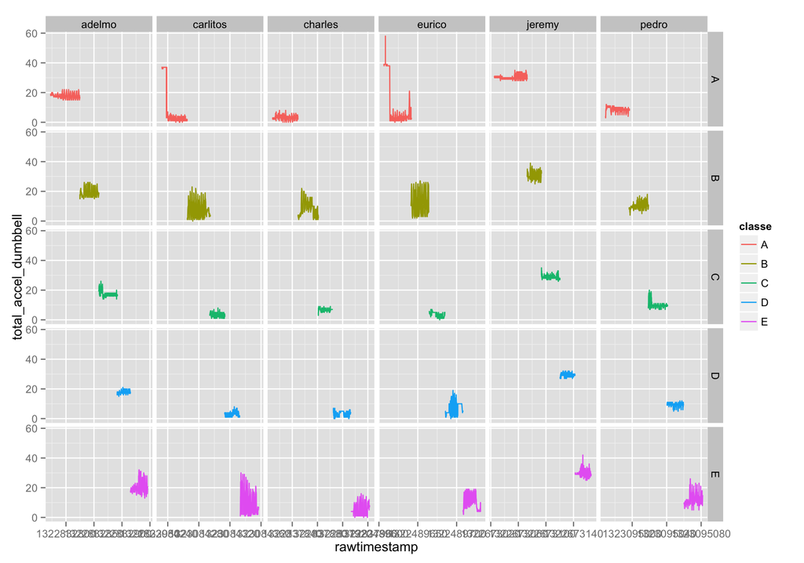

```r
p <- ggplot(training)
p <- p + geom_line(aes(x=rawtimestamp, y=total_accel_dumbbell)) + aes(colour=classe)
p <- p + facet_grid(classe ~ user_name, scales = "free_x")
p
```

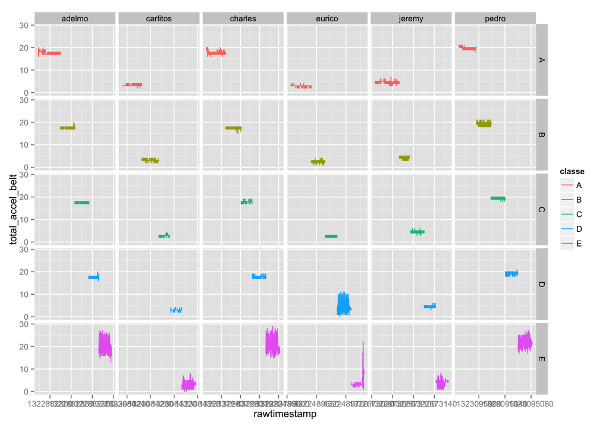

```r
p <- ggplot(training)
p <- p + geom_line(aes(x=rawtimestamp, y=total_accel_belt)) + aes(colour=classe)
p <- p + facet_grid(classe ~ user_name, scales = "free_x")
p
```

# Model Creation

## Data Splitting

```r
set.seed(123)
inTrain <- createDataPartition(training$classe, p = .75,)[[1]]
# remove timestamp, classes and user_name from predictors
trainsetOutcome <- training[inTrain,2]
trainsetPredictor <- training[inTrain,-(1:3)]
testsetOutcome <- training[-inTrain,2]
testsetPredictor <- training[-inTrain,-(1:3)]
```

## Feature selection

### Near Zero Variance

```r
# Find near zero variance features
nzv <- nearZeroVar(trainsetPredictor, saveMetrics = TRUE)
nzv %>% filter(nzv==TRUE)
```

```
## [1] freqRatio     percentUnique zeroVar       nzv
## <0 rows> (or 0-length row.names)
```

There were no features with near zero variance.

### Identify Correlated Predictors

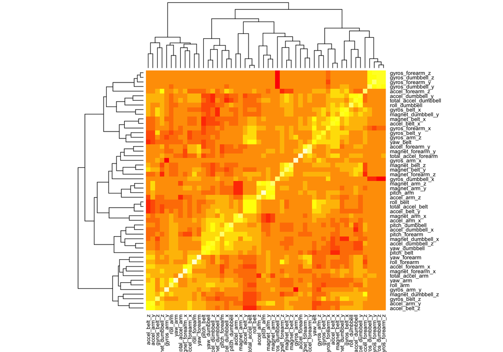

```r
correlationMatrix <- cor(trainsetPredictor)
heatmap(correlationMatrix)
```

```r
highCorrelationFeatureIdx <- findCorrelation(correlationMatrix, cutoff = 0.75)

# remove redundant features
trainSubset <- trainsetPredictor[,-highCorrelationFeatureIdx]
testSubset <- testsetPredictor[,-highCorrelationFeatureIdx]
dim(trainSubset)
```

```
## [1] 14718    31
```

After removing the highly correlated predictors we are down to 31 features. We can now start the processing of these variables.

## Model and Predict

### Scale and center data

```r
set.seed(1)
centerScaledTrainSubset <- preProcess(trainSubset, method=c("center", "scale"))
trainSubsetTransformed <- predict(centerScaledTrainSubset, trainSubset)
testSubsetTransformed <- predict(centerScaledTrainSubset, testSubset)
```

### Model with Rpart

```r
set.seed(1)
control <- trainControl(method="cv", number=10)
modelRpart <- train(trainsetOutcome$classe ~ ., data=trainSubsetTransformed, method="rpart", trControl=control)
importanceRpart <- varImp(modelRpart, scale=FALSE)
```

### Model with boosting

```r
# boosting
set.seed(1)
modelBoosting <- train(trainsetOutcome$classe ~ ., data=trainSubsetTransformed,
                       method="gbm",
                       trControl=control,
                       verbose = FALSE)
importanceBoosting <- varImp(modelBoosting, scale=FALSE)
```

### Model with Random Forest

```r
set.seed(1)
modelRF50 <- train(trainsetOutcome$classe ~ .,
                data=trainSubsetTransformed,
                method="rf",
                trControl=control,
                ntree=50)
importanceRF50 <- varImp(modelRF50, scale=FALSE)
```

```r
set.seed(1)
modelRF100 <- train(trainsetOutcome$classe ~ .,
                data=trainSubsetTransformed,
                method="rf",
                trControl=control,
                ntree=100)
importanceRF100 <- varImp(modelRF100, scale=FALSE)
```

```r
set.seed(1)
modelRF250 <- train(trainsetOutcome$classe ~ .,
                data=trainSubsetTransformed,
                method="rf",
                trControl=control,
                ntree=250)
importanceRF250 <- varImp(modelRF250, scale=FALSE)
```

## Compare models

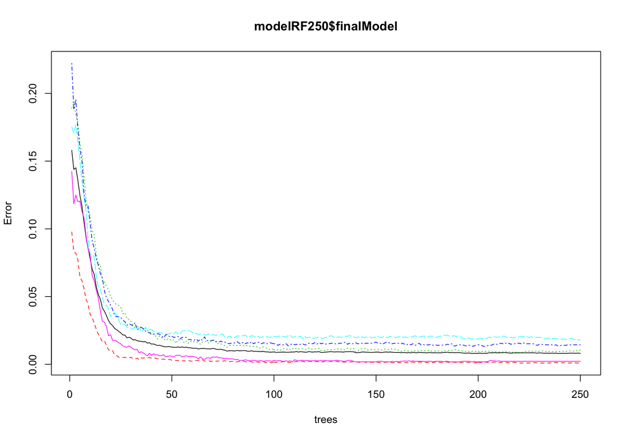

```r
plot(modelRF250$finalModel)
```

```r
results <- resamples(
  list(
    RPART=modelRpart,
    GBM=modelBoosting,
    RF_50=modelRF50,
    RF_100=modelRF100,
    RF_250=modelRF250
    ))
summary(results)
```

```
##
## Call:
## summary.resamples(object = results)
##
## Models: RPART, GBM, RF_50, RF_100, RF_250
## Number of resamples: 10
##
## Accuracy
##          Min. 1st Qu. Median   Mean 3rd Qu.   Max. NA's
## RPART  0.5228  0.5429 0.5579 0.5573  0.5719 0.5918    0
## GBM    0.9409  0.9426 0.9443 0.9452  0.9468 0.9518    0
## RF_50  0.9864  0.9884 0.9888 0.9894  0.9896 0.9939    0
## RF_100 0.9871  0.9912 0.9912 0.9916  0.9925 0.9966    0
## RF_250 0.9885  0.9900 0.9915 0.9916  0.9925 0.9966    0
##
## Kappa
##          Min. 1st Qu. Median   Mean 3rd Qu.   Max. NA's
## RPART  0.4023  0.4258 0.4368 0.4400  0.4554 0.4821    0
## GBM    0.9252  0.9274 0.9295 0.9306  0.9328 0.9390    0
## RF_50  0.9828  0.9854 0.9858 0.9866  0.9869 0.9923    0
## RF_100 0.9837  0.9888 0.9888 0.9894  0.9905 0.9957    0
## RF_250 0.9854  0.9873 0.9893 0.9893  0.9905 0.9957    0
```

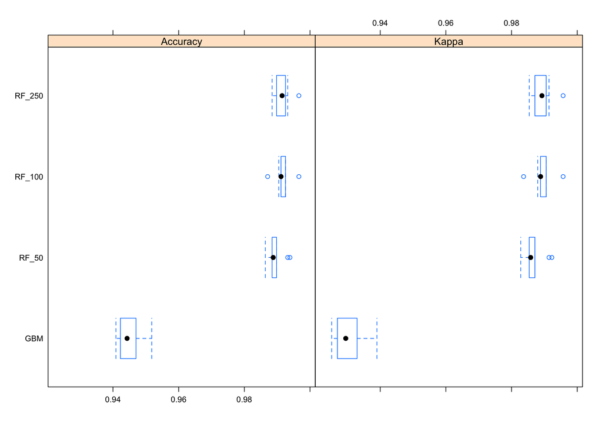

```r
results <- resamples( list(
  GBM=modelBoosting, RF_50=modelRF50,RF_100=modelRF100,
    RF_250=modelRF250
    ))
bwplot(results)
```

## Apply model to test data

```r
set.seed(1)
testConfusionMatrix <- confusionMatrix(testsetOutcome$classe, predict(modelRF50, testSubsetTransformed))
testConfusionMatrix$overall
```

```
##       Accuracy          Kappa  AccuracyLower  AccuracyUpper   AccuracyNull
##      0.9896003      0.9868444      0.9863488      0.9922472      0.2850734
## AccuracyPValue  McnemarPValue
##      0.0000000            NaN
```

Using the test set we calculated an accuracy of 98.96% which translate into an out of sample error rate of 1.04%. So it seems that the model was not over fitting the data.

# References

Velloso, E.; Bulling, A.; Gellersen, H.; Ugulino, W.; Fuks, H. Qualitative Activity Recognition of Weight Lifting Exercises. Proceedings of 4th International Conference in Cooperation with SIGCHI (Augmented Human ’13) . Stuttgart, Germany: ACM SIGCHI, 2013.